# 专题1.1 三角形的三边关系和稳定性【八大题型】（举一反三）（浙教版）（解析版）(1)

## 专题1.1 三角形的三边关系和稳定性【八大题型】

**【浙教版】**

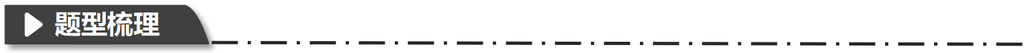

【题型1 三角形的识别与有关概念】 1

【题型2 三角形的分类】 3

【题型3 三角形个数的规律探究题】 5

【题型4 应用三角形的三边关系求第三边长或取值范围】 8

【题型5 应用三角形的三边关系求等腰三角形的边长问题】 10

【题型6 应用三角形的三边关系化简含有绝对值的式子】 12

【题型7 应用三角形的三边关系解决线段的和差比较问题】 14

【题型8 三角形的稳定性】 18

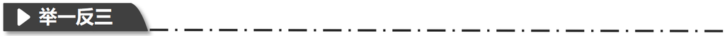

**【知识点1 三角形的概念】**

由不在同一条直线上的三条线段首尾顺次相接所组成的图形叫做三角形.

# **【题型1 三角形的识别与有关概念】**

【答案】B

【分析】三角形是由三条线段首位顺次连接而成的图形.

【详解】解：根据三角形的定义，

A选项不符合三角形的定义；

B选项符合三角形的定义；

C选项不符合三角形的定义；

D选项不符合三角形的定义；

故选B.

【点睛】本题主要考查三角形的定义，解决本题的关键是要熟练掌握三角形的定义.

【变式1-1】（2023春·山东德州·八年级校考阶段练习）下列说法正确的是( )

A．所有的等腰三角形都是锐角三角形

B．等边三角形属于等腰三角形

C．不存在既是钝角三角形又是等腰三角形的三角形

D．一个三角形里有两个锐角，则一定是锐角三角形

【答案】B

【分析】根据锐角三角形、钝角三角形、等腰三角形的定义一一判断即可．

【详解】A选项：内角为30°，30°，120°的等腰三角形是钝角三角形，故是错误的．

B选项：等边三角形属于等腰三角形，故正确．

C选项：内角为30°，30°，120°的三角形既是钝角三角形又是等腰三角形的三角形，故错误．

D选项：内角为30°，30°，120°的三角形有两个锐角，是钝角三角形，故错误．

故选B．

【点睛】考查三角形的一个概念，解题的关键是搞清楚锐角三角形、钝角三角形、等腰三角形的定义．

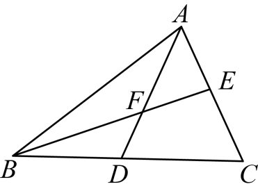

(1) △ *B**D**F*的三个顶点是什么?三条边是什么?

(2)$AB$是哪些三角形的边?

【答案】(1) △ *B**D**F*的三个顶点是点*B*，*D*，*F*，三条边是$BF$，$BD$，$DF$

(2)$AB$是 △ *A**B**E*， △ *A**B**F*， △ *A**B**D*， △ *A**B**C*的边

【分析】（1）根据三角形的边和顶点解答即可；

（2）根据三角形的边解答即可．

【详解】（1）解： △ *B**D**F*的三个顶点是点*B*，*D*，*F*，三条边是$BF$，$BD$，$DF$；

（2）解：$AB$是 △ *A**B**E*， △ *A**B**F*， △ *A**B**D*， △ *A**B**C*的边．

【点睛】本题考查三角形，解题的关键是掌握三角形的角和边的概念．

【变式1-3】（2023·浙江·八年级假期作业）如图，在△*BCE*中，边*BE*所对的角是________，∠*CBE*所对的边是________；在△*AEC*中，边*AE*所对的角是________，∠*A*为内角的三角形是________．

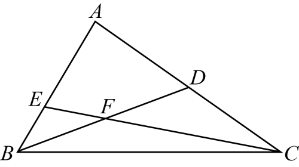

【答案】 ∠*BCE* *CE*/*EC* ∠*ACE* △*ABD*，△*ABC*，△*ACE*

【分析】根据的边、角的定义，即可求解．

【详解】解：在△*BCE*中，边*BE*所对的角是∠*BCE*，∠*CBE*所对的边是*CE*；

在△*AEC*中，边*AE*所对的角是∠*ACE*，∠*AEC*所对的边是*AC*；

∠*A*为内角的三角形是△*ABD*，△*ABC*，△*ACE*．

故答案为：∠*BCE*；*CE*；∠*ACE*；△*ABD*，△*ABC*，△*ACE*

【点睛】本题考查了三角形的知识，掌握由不在同一条直线上的三条线段首尾顺次相接所组成的图形叫做三角形；组成三角形的线段叫做三角形的边；相邻两边的公共端点叫做三角形的顶点；相邻两边组成的角叫做三角形的内角，简称三角形的角是解题的关键．

**【知识点2 三角形的分类】**

按边分类：三角形$\left\{ \begin{matrix} 三边都不相等的三角形\text{\ \ \ \ \ \ \ \ \ \ \ \ \ \ \ \ \ \ \ \ \ \ \ \ \ \ \ \ \ \ \ \ \ \ \ \ \ \ \ } \\ 等腰三角形\left\{ \begin{matrix} 底边和腰不相等的等腰三角形 \\ 等边三角形\text{\ \ \ \ \ \ \ \ \ \ \ \ \ \ \ \ \ \ \ \ \ \ \ \ \ \ \ \ \ \ \ \ \ \ \ \ } \\ \end{matrix} \right.\ \\ \end{matrix} \right.\$

按角分类：三角形$\left\{ \begin{matrix} 直角三角形\text{\ \ \ \ \ \ \ \ \ \ \ \ \ \ \ \ \ \ \ \ \ \ \ \ \ } \\ 斜三角形\left\{ \begin{matrix} 锐角三角形 \\ 钝角三角形\text{\ \ } \\ \end{matrix} \right.\ \\ \end{matrix} \right.\$

# **【题型2 三角形的分类】**

【例2】（2023春·全国·八年级专题练习）如图表示的是三角形的分类，则正确的表示是（ ）

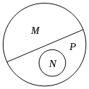

A．*M*表示三边均不相等的三角形，*N*表示等腰三角形，*P*表示等边三角形

B．*M*表示三边均不相等的三角形，*N*表示等边三角形，*P*表示等腰三角形

C．*M*表示等腰三角形，*N*表示等边三角形，*P*表示三边均不相等的三角形

D．*M*表示等边三角形，*N*表示等腰三角形，*P*表示三边均不相等的三角形

【答案】B

【分析】根据三角形按照边的分类方法解答．

【详解】解：根据三角形的分类，三角形可以分为三边都不相等的三角形和等腰三角形，等腰三角形分为底边和腰不相等的三角形和底边三角形，

故选择B．

【点睛】本题考查三角形的分类，牢记三角形按照边的分类方法是解决问题的关键．

【变式2-1】（2023春·八年级单元测试）现有以下说法：①等边三角形是等腰三角形；②三角形的两边之差大于第三边；③三角形按边分类可分为不等边三角形、等腰三角形、等边三角形；④三角形按角分类可分为锐角三角形、直角三角形和钝角三角形．正确的有（ ）

A．4个 B．3 个 C．2个 D．1个

【答案】C

【分析】根据三角形的分类，三角形的三边关系，逐项分析判断即可求解．

【详解】解：①等边三角形是等腰三角形，故①正确；

②三角形的两边之差小于第三边，故②错误；

③三角形按边分为等腰三角形、等边三角形和三边都不相等的三角形，的说法是错误的（因为等边三角形属于等腰三角形），故③错误

④三角形按角分类应分为锐角三角形、直角三角形和钝角三角形，故④正确

∴上述说法中正确的有2个.

故选：C．

【点睛】本题考查了三角形的分类，三角形的三边关系，熟练掌握三角形的分类是解题的关键．

【变式2-2】（2023春·八年级课时练习）如图，∠ACD＝90°，则图中的锐角三角形是_________，钝角三角形有______个．

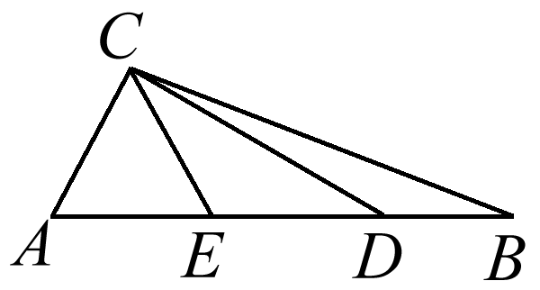

【答案】 △ACE； 4.

【分析】三个角都是锐角的三角形是锐角三角形；有一个角是直角的三角形是直角三角形；有一个角是钝角的三角是钝角三角形；有两条边相等的三角形是等腰三角形，三条边相等的三角形是等边三角形（是特殊的等腰三角形），根据三角形按角分类的方法进行逐项分类即可．

【详解】观察图形可知，△ACE是锐角三角形，；

△CED、△CDB、△CEB、△ACB是钝角三角形，共4个.

故答案为△ACE，4．

【点睛】本题是考查三角形的分类．

【答案】C

【分析】根据三角形按角分类的方法一一判断即可．

【详解】解：观察图形可知：

A、露出的角是直角，因此是直角三角形；

B、知道两个角，可以计算出第三个角的度数，因此可以判断出三角形类型；

C、露出的角是锐角，其他两角都不知道，因此不能判断出三角形类型；

D、露出的角是钝角，因此是钝角三角形．

故选：C．

【点睛】本题考查了三角形的分类，解题的关键是仔细观察图形，熟练掌握基本知识．

# **【题型3 三角形个数的规律探究题】**

【例3】（2023春·全国·八年级专题练习）根据下图所示的形⑴、⑵、⑶三个图所表示的规律，依次下去第*n*个图中的三角形的个数是( )

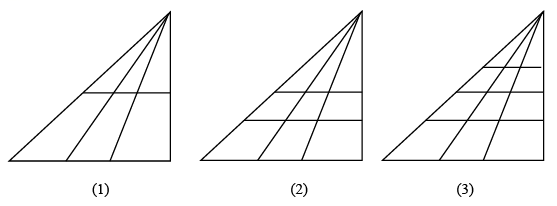

A．6(*n*-1) B．6*n* C．6(*n*+1) D．12*n*

【答案】C

【分析】从这三个图中找规律，可以先分别找出每个图形中三角形的个数，再分析三个数字之间的关系，从而得出第*n*个图形中三角形的个数．

【详解】图（1）中，三角形的个数是$6 + 6 = 6 × 2$ ,

图（2）中，三角形的个数是$6 + 6 + 6 = 6 × 3$ ,

图（3）中，三角形的个数是$6 + 6 + 6 + 6 = 6 × 4$ ,

第*n*个图形中三角形的个数是6 ⋅ (*n* + 1)，

故选：C．

【点睛】本题考查了图形的变化规律，利用图形之间的练习，得出数字间的运算规律，从而解决问题，体现了从特殊到一般的数学思想．

【变式3-1】（2023春·八年级单元测试）若有一条公共边的两个三角形称为一对“共边三角形”，则图中以$BC$为公共边的“共边三角形”有___________对．

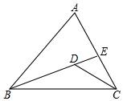

【答案】3

【分析】找到以$BC$为边的三角形，即可得解．

【详解】解：以$BC$为公共边的“共边三角形”有 △ *B**D**C*与 △ *B**E**C*、 △ *B**D**C*与 △ *B**A**C*、 △ *B**E**C*与 △ *B**A**C*共3对．

故答案为：3．

【点睛】本题考查三角形的定义．理解并掌握“共边三角形”的定义，是解题的关键．

【答案】10

【分析】以平面内的五个点为顶点画三角形，根据三角形的定义，我们在平面中依次选取三个点画出图形即可解答.

故答案为：10．

【点睛】本题考查的是几何图形的个数，我们根据三角形的定义，在画图的时候要注意按照一定的顺序，保证不重复不遗漏.

【变式3-3】（2023春·全国·八年级专题练习）（1）如图1，*D<sub>1</sub>*是△*ABC*的边*AB*上的一点，则图中有哪几个三角形？

（2）如图2，*D<sub>1</sub>*，*D<sub>2</sub>*是△*ABC*的边*AB*上的两点，则图中有哪几个三角形？

（3）如图3，*D<sub>1</sub>*，*D<sub>2</sub>*，…，*D<sub>10</sub>*是△*ABC*的边*AB*上的10个点，则图中共有多少个三角形？

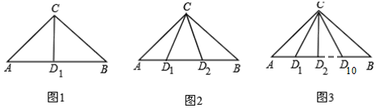

【答案】（1）3；（2）6；（3）66．

【分析】（1）根据三角形的概念：由不在同一直线上的三条线段首尾顺次相接所组成的图形叫做三角形进行分析即可；

（2）根据三角形的定义结合图形进行分析即可得；

（3）根据直线AB上有几条线段就有几个三角形，由线段的计数方法进行计算即可得答案.

【详解】（1）图中三角形有：△ABC、△AD<sub>1</sub>C、△AD<sub>1</sub>B共3个；

（2）图中三角形有：△ACD<sub>1</sub>、△ACD<sub>2</sub>、△ABC、△D<sub>1</sub>CD<sub>2</sub>、△D<sub>1</sub>CB、△D<sub>2</sub>CB共6个；

（3）∵直线AB上有12个点，

∴直线AB上的线段共有：$\frac{12 \times \left( 12 - 1 \right)}{2}$=66（条），即图中共有66个三角形．

【点睛】本题考查了三角形，规律题，关键在数三角形个数时要做到不重不漏.

**【知识点3 三角形的三边关系】**

三角形两边的和大于第三边，两边的差小于第三边.

在运用三角形三边关系判定三条线段能否构成三角形时并不一定要列出三个不等式，只要两条较短的线段长度之和大于第三条线段的长度即可判定这三条线段能构成一个三角形．

# **【题型4 应用三角形的三边关系求第三边长或取值范围】**

【例4】（2023·江西上饶·八年级统考期末）已知三角形三边长分别为*m，n，k*，且*m、n*满足|*n* − 9| + (*m* − 5)<sup>2</sup> = 0，则这个三角形最长边*k*的取值范围是________．

【答案】9 ≤ *k* < 14

【分析】根据|*n* − 9| + (*m* − 5)<sup>2</sup> = 0求出m、n的长，根据三角形三边关系求出k的取值范围，再根据k为最长边进一步即可确定k的取值．

【详解】解：由题意得n-9=0，m-5=0，

解得 m=5，n=9，

∵*m，n，k*，为三角形的三边长，

∵k为三角形的最长边，

∴9 ≤ *k* < 14．

故答案为：9 ≤ *k* < 14

【点睛】本题考查了绝对值、偶次方的非负性，三角形的三边关系，根据题意求出m、n的长是解题关键，确定k的取值范围时要注意k为最长边这一条件．

【变式4-1】（2023春·八年级课时练习）下列长度的三条线段能组成三角形吗？请说明理由．

(1)20*c**m*，15*c**m*，8*c**m*．

(2)7*c**m*，15*c**m*，8*c**m*．

(3)5*c**m*，15*c**m*，8*c**m*．

【答案】(1)20*c**m*，15*c**m*，8*c**m*这三条线段能组成三角形，理由见解析

(2)7*c**m*，15*c**m*，8*c**m*这三条线段不能组成三角形，理由见解析

(3)5*c**m*，15*c**m*，8*c**m*这三条线段不能组成三角形，理由见解析

【分析】根据构成三角形的条件进行逐一判断即可．

【详解】（1）解；20*c**m*，15*c**m*，8*c**m*这三条线段能组成三角形，理由如下：

∵$20 − 8 < 15 < 20 + 8$，

∴20*c**m*，15*c**m*，8*c**m*这三条线段能组成三角形；

（2）解；7*c**m*，15*c**m*，8*c**m*这三条线段不能组成三角形，理由如下：

∵$7 + 8 = 15$，

∴7*c**m*，15*c**m*，8*c**m*这三条线段不能组成三角形；

（3）解；5*c**m*，15*c**m*，8*c**m*这三条线段不能组成三角形，理由如下：

∵$5 + 8 < 15$，

∴5*c**m*，15*c**m*，8*c**m*这三条线段不能组成三角形．

【点睛】本题主要考查了构成三角形的条件，熟知三角形任意两边之和大于第三边，任意两边之差小于第三边是解题的关键．

【变式4-2】（2023春·江苏·八年级专题练习）已知三角形三边分别为*a*、*b*、*c*，其中*a*、*b*满足$\left| a - b \right| + \sqrt{b - 3} = 0$，那么*c*的取值范围是______．

【答案】0 < *c* < 6

【分析】首先根据非负数的性质计算*a*、*b*的值，然后根据三角形三边的关系可得*c*的取值范围．

【详解】解：∵$\left| a - b \right| + \sqrt{b - 3} = 0$，

∴*a* − *b* = 0，*b* − 3 = 0，

∴*a* = 3，*b* = 3，

∴3 − 3 < *c* < 3 + 3，

∴0 < *c* < 6．

故答案为：0 < *c* < 6．

【点睛】本题主要考查了非负数的性质和三角形三边关系，根据非负数的性质确定*a*、*b*的值是解题关键．

【变式4-3】（2023春·黑龙江绥化·八年级校联考期中）若一个三角形的两边长是4和9，且周长是偶数，则第三边长为_______．

【答案】7或9或11

【详解】解：设第三边为*a*，根据三角形的三边关系可得：9 − 4 < *a* < 9 + 4．

即：5 < *a* < 13，

∵周长是偶数，

∴第三边的长为奇数，即：*a* = 7或*a* = 9或*a* = 11．

∴第三边长为7或9或11．

故答案为：7或9或11．

【点睛】此题主要考查了三角形的三边关系，关键是掌握任意两边之和大于第三边，任意两边之差小于第三边．

# **【题型5 应用三角形的三边关系求等腰三角形的边长问题】**

【例5】（2023春·山东威海·八年级校联考期中）等腰三角形的周长为20，一边长为8，则它的腰长为（ ）

A．6 B．4 C．8或6 D．8或4

【答案】C

【分析】根据等腰三角形的性质分为两种情况解答：当腰长为8或者底边为8时．

【详解】解：分两种情况考虑：

（1）当8是腰长时，则底边长是20-8-8=4，此时8，8，4能组成三角形；

（2）当8是底边长时，腰长是（20-8）×$\frac{1}{2}$＝6，此时8，6，6能组成三角形.

综上，腰长是8或6．

故选C．

【点睛】本题考查了等腰三角形的性质和三角形的三边关系；已知没有明确腰和底边的题目一定要想到两种情况，分类进行讨论，还应验证各种情况是否能构成三角形进行解答，这点非常重要，也是解题的关键．

【变式5-1】（2023春·湖北武汉·八年级校联考阶段练习）一个等腰三角形的两边长分别是 a和 2a＋1（a＞0），则它的周长为（ ）

A．3a＋1 B．4a＋1 C．5a＋2 D．4a＋1 或 5a＋2

【答案】C

【分析】根据等腰三角形的性质及三角形的三边关系即可求解.

【详解】∵一个等腰三角形的两边长分别是 a和 2a＋1

∴另一边可能是a，或2a+1，

∵a+a=2a＜2a+1

故第三边为2a+1，

故周长为a+2a+1+2a+1= 5a＋2

故选C.

【点睛】此题主要考查等腰三角形的性质，解题的关键是熟知三角形的三边关系.

【变式5-2】（2023春·山东潍坊·八年级统考期末）(多选题)已知等腰三角形的周长是12，且各边长都为整数，则各边的长可能是（ ）．

A．2，2，8 B．5，5，2 C．4，4，4 D．3，3，5

【答案】BC

【分析】根据三角形三边之间的关系：两边之和大于第三边，两边之差小于第三边．结合题目条件“周长为12”，可得出正确答案．

【详解】A.2+2<8，不能组成三角形，排除．

B.5+5>2，5-5<2；且5+5+2=12；满足题意．

C.4+4>4，4-4<4；且4+4+4=12；满足题意．

D.3+3>5，3-3<5；但3+3+5≠12；排除．

故选：BC．

【点睛】本题主要考查了能够组成三角形三边之间的关系：两边之和大于大三边，两边之差小于第三边；注意结合题目条件“周长为12”．

【变式5-3】（2023春·八年级课时练习）若二元一次方程组$\left\{ \begin{matrix} x + 2y = m + 3 \\ x + y = 2m \\ \end{matrix} \right.\$的解*x*、*y*的值恰好是一个等腰三角形两边的长，且这个等腰三角形的周长为7，则*m*的值为______．

【答案】2

【分析】解二元一次方程组，分三种情况考虑，根据周长为7得关于*m*的方程，求得*m*，根据构成三角形的条件判断即可．

【详解】$\left\{ \begin{matrix} x + 2y = m + 3① \\ x + y = 2m② \\ \end{matrix} \right.\$

①-②得：y=3-*m*

把*y*=3-*m*代入②，得*x*=3*m*-3

故方程组的解为$\left\{ \begin{matrix} x = 3m - 3 \\ y = 3 - m \\ \end{matrix} \right.\$

若*x*为腰，*y*为底，则2*x*+*y*=7

即2(3*m*-3)+3-*m*=7

解得：*m*=2

此时*x*=3，*y*=1，满足构成三角形的条件

若*y*为腰，*x*为底，则2*y*+*x*=7

即2(3-*m*)+3*m*-3=7

解得：*m*=4

此时*x*=9，*y*=-1，不合题意

若*x*=*y*，即3*m*-3=3-*m*

解得：$m = \frac{3}{2}$

此时腰为$\frac{3}{2}$，底为$7 - 2 \times \frac{3}{2} = 4$

但$\frac{3}{2}$+$\frac{3}{2}$<4，不符合构成三角形的条件

故不合题意

所以满足条件的*m*为2

故答案为：2

【点睛】本题考查了二元一次方程组的解法，一元一次方程的解法，三条线段构成三角形的条件，涉及分类讨论思想，方程思想，要注意的是，求出m的值后，要验证是否符合构成三角形的条件．

# **【题型6 应用三角形的三边关系化简含有绝对值的式子】**

【例6】（2023春·全国·八年级专题练习）已知 △ *A**B**C*的三边长分别为3、5、*a*，化简|*a*−2| − |*a*−1| + |*a*−8|的结果为___________．

【答案】7 − *a*

【分析】直接利用三角形三边关系进而得出*a*的取值范围，进而利用绝对值的性质化简得出答案．

【详解】解：∵ △ *A**B**C*的三边长分别为3、5、*a*，

∴5 − 3 < *a* < 5 + 3，

解得：2 < *a* < 8，

故|*a*−2| − |*a*−1| + |*a*−8|．

= *a* − 2 − (*a*−1) − (*a*−8)

= *a* − 2 − *a* + 1 − *a* + 8

= 7 − *a*．

故答案为：7 − *a*．

【点睛】本题考查的是绝对值的化简，整式的加减运算的应用，三角形的三边关系的应用，熟练的化简绝对值是解本题的关键．

【变式6-1】（2023春·广东茂名·八年级校考阶段练习）若*a*，*b*，*c*是 △ *A**B**C*的三边，则化简|*a*−*b*−*c*| − |*b*+*a*−*c*|的结果是（ ）

A．2*b* − 2*a* B．2*c* − 2*a* C．2*b* D．0

【答案】B

【分析】根据三角形的三边关系“任意两边之和大于第三边，任意两边之差小于第三边”，得到*a* − *b* − *c* < 0，*a* + *b* − *c* > 0，再根据绝对值的性质进行化简计算．

【详解】解：根据三角形的三边关系，得

*a* − *b* − *c* < 0，*a* + *b* − *c* > 0，

∴原式 = *c* + *b* − *a* − (*b*+*a*−*c*)

= *c* + *b* − *a* − *b* − *a* + *c*

= 2*c* − 2*a*

故选：B．

【点睛】本题考查三角形三边关系和绝对值，解题的关键是熟练掌握三角形三边关系．

【变式6-2】（2023春·浙江杭州·八年级杭州外国语学校校考期末）已知三角形三条边的长度为3，*x*，9，化简：|*x*﹣2|＋|*x*﹣13|＝____

【答案】11

【详解】解：∵三角形的三边长分别是3、*x*、9，

∴6＜*x*＜12，

∴*x*﹣2＞0，*x*﹣13＜0，

∴|*x*−2| + |*x*−13|＝*x*﹣2＋13﹣*x*＝11，

故答案为：11．

【点睛】本题考查三角形的三边关系和绝对值的化简．三角形两边之和大于第三边，两边之差小于第三边．

【变式6-3】（2023春·八年级单元测试）已知*a*，*b*，*c*是 △ *A**B**C*的三边长．

（1）若*a*，*b*，*c*满足，(*a* − *b*)<sup>2</sup> + |*b* − *c*| = 0，试判断 △ *A**B**C*的形状；

（2）化简：|*b* − *c* − *a*| + |*a* − *b* + *c*| − |*a* − *b* − *c*|

【答案】（1） △ *A**B**C*是等边三角形；（2）3*a* − 3*b* + *c*

【分析】（1）由性质可得*a*=*b*，*b*=*c*，故 △ *A**B**C*为等边三角形．

（2）根据三角形任意两边和大于第三边，任意两边差小于第三边判定正负，再由绝对值性质去绝对值计算即可．

【详解】（1）∵(*a* − *b*)<sup>2</sup> + |*b* − *c*| = 0

∴(*a* − *b*)<sup>2</sup> = 0且|*b* − *c*| = 0

∴*a* = *b* = *c*

∴ △ *A**B**C*是等边三角形．

（2）∵*a*，*b*，*c*是 △ *A**B**C*的三边长

∴*b*-*c*-*a*<0,*a*-*b*+*c*>0,*a*-*b*-*c*<0

原式=| − (*a* + *c* − *b*)| + (*a* − *b* + *c*) − | − (*b* + *c* − *a*)|

=*a* + *c* − *b* + *a* − *b* + *c* − *b* − *c* + *a*

=3*a* − 3*b* + *c*

【点睛】本题考查了三角形三条边的关系以及绝对值化简，根据三角形任意两边和大于第三边，任意两边差小于第三边判定绝对值内数值正负是解题的关键．

# **【题型7 应用三角形的三边关系解决线段的和差比较问题】**

【例7】（2023春·八年级课时练习）如图，已知点*O*为 △ *A**B**C*内任意一点，证明：*A**B* + *A**C* + *B**C* > *O**A* + *O**B* + *O**C*．

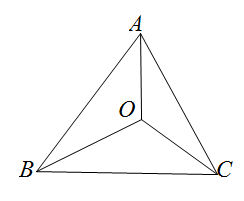

【答案】见解析

【分析】延长*BO*交*AC*于点*D*，根据三角形三边关系进行求解即可；

【详解】如图，延长*BO*交*AC*于点*D*．

在 △ *A**B**D*中，*A**B* + *A**D* > *B**D*，①

在 △ *O**D**C*中，*O**D* + *C**D* > *O**C*，②

①+②，得*A**B* + *A**D* + *O**D* + *C**D* > *B**D* + *O**C*．

∵*B**D* = *O**B* + *O**D*，*A**D* + *C**D* = *A**C*，

∴ *A**B* + *A**C* + *O**D* > *O**B* + *O**D* + *O**C*，

∴ *A**B* + *A**C* > *O**B* + *O**C*，③

同理可证*A**B* + *B**C* > *O**A* + *O**C*，④ *A**C* + *B**C* > *O**A* + *O**B*，⑤

③+④+⑤，得2(*A**B* + *A**C* + *B**C*) > 2(*O**A* + *O**B* + *O**C*)，即*A**B* + *A**C* + *B**C* > *O**A* + *O**B* + *O**C*．

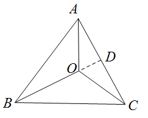

【点睛】本题主要考查了三角形三边关系的应用，准确理解是解题的关键．

【变式7-1】（2023春·安徽宿州·八年级校考期中）如图，*D*为 △ *A**B**C*的边$BC$上一点，试判断2*A**D*与 △ *A**B**C*的周长之间的大小关系，并加以证明．

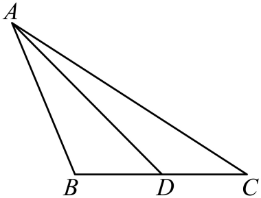

【答案】 △ *A**B**C**的**周**长* > 2*A**D*，见解析

【分析】根据三角形的三边关系，两边之和大于第三边，即可得出答案．

【详解】证明：∵在 △ *A**B**D*中，*A**B* + *B**D* > *A**D*，

在 △ *A**C**D*中，*A**C* + *C**D* > *A**D*，

∴*A**B* + *B**D* + *A**C* + *C**D* > 2*A**D*，

即*A**B* + *B**C* + *A**C* > 2*A**D*，

∴ △ *A**B**C**的**周**长* > 2*A**D*

【点睛】本题考查了三角形的三边关系，熟记其三边关系是解题的关键．

【变式7-2】（2023春·八年级统考课时练习）已知点*O*在 △ *A**B**C*内部，连接*OA*，*OB*，*OC*，说明：$\frac{1}{2}(AB + AC + BC) < OA + OB + OC < AB + AC + BC$．

【答案】证明见解析

【分析】延长*BO*交*AC*于*D*．在△*AOB*、△*BOC*、△*AOC*中，由三角形三边关系定理列式，三式相加可得2(*OA*+*OB*+*OC*)＞*AB*+*BC*+*AC*，即可证明不等式左边部分成立．在△*ADO*、△*BDC*中，由三角形三边关系定理列式，两式相加可得*OA*+*BO*＜*AC*+*BC*，同理可得：*OC*+*OB*＜*AB*+*AC*，*OC*+*OA*＜*AB*+*BC*，三式相加即可证明不等式右边部分成立．

【详解】延长*BO*交*AC*于*D*．

在 △ *A**O**B*中，*O**A* + *O**B* > *A**B*，①

在 △ *B**O**C*中*O**C* + *O**B* > *B**C*，②

在 △ *A**O**C*中，*O**C* + *O**A* > *A**C*，③

①＋②＋③得2(*O**A*+*O**B*+*O**C*) > *A**B* + *B**C* + *A**C*．

即$OA + OB + OC > \frac{1}{2}(AB + BC + AC)$．

在△*ADO*中，*OA*＜*AD*+*OD*，

在△*BDC*中，*BD*＜*DC*+*BC*，

∴*OA*+*BD*＜*AD*+*OD*+*DC*+*BC*，

即*OA*+*BO*+*OD*＜*AC*+*OD*+*BC*，

∴*OA*+*BO*＜*AC*+*BC* ④

同理：*O**C* + *O**B* < *A**B* + *A**C* ⑤

*O**C* + *O**A* < *A**B* + *B**C*，⑥

④＋⑤＋⑥得2(*О**A* + *O**B* + *O**C*) < 2(*A**B* + *B**C* + *A**C*)，

即*O**A* + *O**B* + *O**C* < *A**B* + *B**C* + *A**C*．

∴$\frac{1}{2}(AB + BC + AC) < OA + OB + OC < AB + BC + AC$．

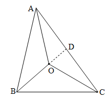

【点睛】本题考查了三角形的三边关系，即三角形任意两边之和大于第三边，任意两边之差小于第三边．

【变式7-3】（2023春·全国·八年级专题练习）观察并探求下列各问题：

(1)如图①，在△*ABC*中，*P*为边*BC*上一点，则*BP*＋*PC*__ __*AB*＋*AC*(填“＞”“＜”或“＝”)．

(2)将(1)中的点*P*移到△*ABC*内，得图②，试观察比较△*BPC*的周长与△*ABC*的周长的大小，并说明理由．

(3)将(2)中的点*P*变为两个点*P*<sub>1</sub>，*P*<sub>2</sub>，得图③，试观察比较四边形*BP*<sub>1</sub>*P*<sub>2</sub>*C*的周长与△*ABC*的周长的大小，并说明理由．

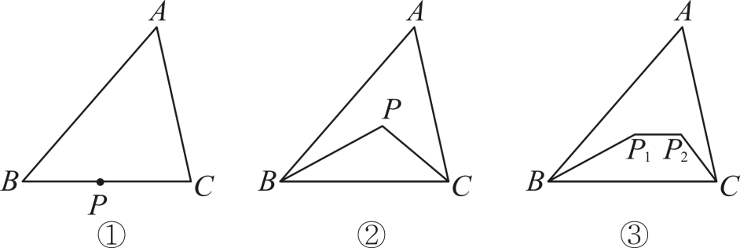

【答案】（1）＜；（2）＜；（3）＜.

【详解】试题分析：（1）根据三角形中两边之和大于第三边，即可得出结果，

（2）可延长BP交AC与M，根据两边之和大于第三边，即可得出结果，

（3）分别延长BP<sub>1</sub>、CP<sub>2</sub>交于M，再根据（2）中得出的BM+CM＜AB+AC，可得出BP<sub>1</sub>+P<sub>1</sub>P<sub>2</sub>+P<sub>2</sub>C＜BM+CM＜AB+AC，即可得出结果．

试题解析：（1）BP+PC＜AB+AC，理由：三角形两边之和大于第三边，

（2）△BPC的周长＜△ABC的周长．理由：

如图，延长BP交AC于M，在△ABM中，BP+PM＜AB+AM，在△PMC中，PC＜PM+MC，两式相加得BP+PC＜AB+AC，于是得：△BPC的周长＜△ABC的周长，

（3）四边形BP<sub>1</sub>P<sub>2</sub>C的周长＜△ABC的周长，理由：

如图，分别延长BP<sub>1</sub>、CP<sub>2</sub>交于M，由（2）知，BM+CM＜AB+AC，又P<sub>1</sub>P<sub>2</sub>＜P<sub>1</sub>M+P<sub>2</sub>M，

可得，BP<sub>1</sub>+P<sub>1</sub>P<sub>2</sub>+P<sub>2</sub>C＜BM+CM＜AB+AC，可得结论.

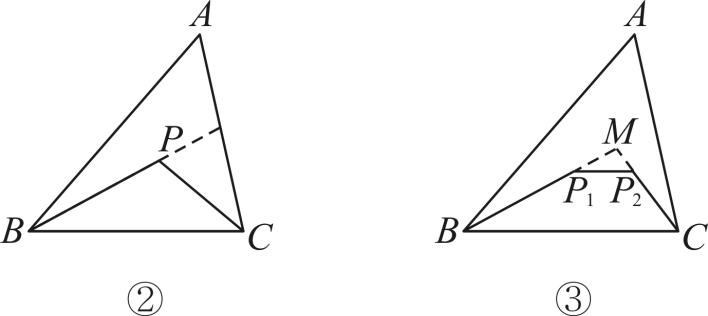

**【知识点4 三角形的稳定性】**

当三角形三边的长度确定后，三角形的形状和大小就能唯一确定下来，故三角形具有稳定性．这一特性主要应用在实际生活中.

# **【题型8 三角形的稳定性】**

【例8】（2023春·山东临沂·八年级统考期中）在实际生活中，我们经常利用一些几何图形的稳定性或不稳定性，下列实物图中利用了稳定性的是（ ）

A．电动伸缩门

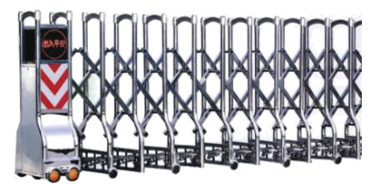

B．升降台

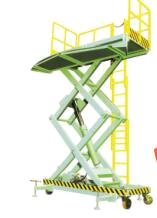

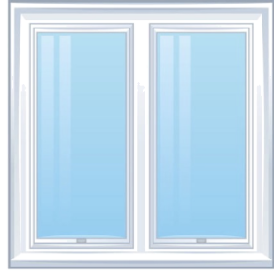

【答案】C

【分析】根据三角形具有稳定性和四边形具有不稳定性进行辨别即可.

【详解】A. 由平行四边形的特性可知，平行四边形具有不稳定性，所以容易变形，伸缩门运用了平行四边形易变形的特性；

B. 升降台也是运用了四边形易变形的特性；

D.窗户是由四边形构成，它具有不稳定性.

故选C.

【点睛】此题主要考查了平行四边形的特性是容易变形以及三角形具有稳定性．

【变式8-1】（2023春·广东梅州·八年级校联考开学考试）如图，自行车的三角形支架，这是利用三角形具有_______性．

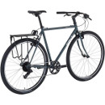

【答案】稳定

【分析】三角形具有稳定性．

【详解】自行车的三角形车架，这是利用了三角形的稳定性．

故答案为：稳定性．

【点睛】本题考查了三角形的稳定性，解题的关键在于将三角形的稳定性与自行车的三角形具有稳定性联系起来．

【变式8-2】（2023春·八年级单元测试）为使五边形木架（用5根木条钉成）不变形，哥哥准备如图①那样再钉上两根木条，弟弟准备如图②那样再钉上两根木条，哪种方法能使木架不变形？为什么？

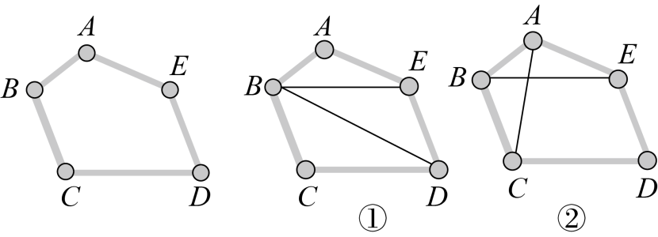

【答案】见解析

【分析】根据三角形具有稳定性解答即可．

【详解】解：哥哥的如图①那样钉上两根木条能使木架不变形，

因为三角形具有稳定性．

【点睛】本题考查了三角形的稳定性，理解概念是解题的关键．

【变式8-3】（2023春·贵州黔西·八年级校考阶段练习）如图，六根木条钉成一个六边形框架ABCDEF，根据三角形的稳定性要使框架稳固且不活动，至少还需要添_______根木条．

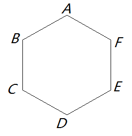

【答案】3

【分析】根据三角形的稳定性，只要使六边形框架ABCDEF变成三角形的组合体即可．

【详解】解：

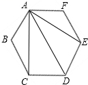

根据三角形的稳定性，得

如图：从图中可以看出，要使框架稳固且不活动，至少还需要添3根木条．

故答案为:3.

【点睛】本题主要考查的是三角形的稳定性．